# Supplementary Code: Transgenerational inheritance of impaired larval T cell development in zebrafish

Norimasa Iwanami, Divine-Fondzenyuy Lawir, Katarzyna Sikora, Connor O’Meara, Kohei Takeshita, Michael Schorpp, Thomas Boehm

## **Summary**

This document provides the R code and accompanying explanations to reproduce Figures 1 e-f, 6 a-d, 7 b as well as Supplementary Figures 2 b-d and 5 a from the manuscript with working title “Transgenerational inheritance of impaired larval T cell development in zebrafish” by Iwanami et al..  
The analysis starts with SNP and coverage-filtered methylation ratios as well as tables with results of differential methylation analysis and walks the reader through the data processing underlying the manuscript figures. A copy of this document will be deposited on GitHub under https://github.com/katsikora/Iwanami2019_SupplementaryCodeAndData_A upon publication. The code is formatted in a way to facilitate understanding and interpretation by a lay R user. This code is authored by Katarzyna Sikora.

#### Input data

Input data (methylation matrices saved in the binary RData format) can be obtained under:

- Figure 1e: “https://owncloud.gwdg.de/index.php/s/yukRgs4sCCaIJBh/download” (zebrafish larvae single CpG methylation values),
- Figure 1f and Figure 6a left panel: “https://owncloud.gwdg.de/index.php/s/rnhnQNXbsT6MyuK/download” (zebrafish sperm single CpG methylation values),
- Figure 6a right panel: “https://owncloud.gwdg.de/index.php/s/yBqvW1OFSA57lC9/download” (zebrafish G4 sperm single CpG methylation values),
- Figure 6b: “https://owncloud.gwdg.de/index.php/s/sHTiST0yjvMEXv6/download” (zebrafish G4 sperm unchanged candidate DMRs re-evaluation in G2 sperm, RData format); “https://owncloud.gwdg.de/index.php/s/IC1SivxF5Kh3xmH/download” (zebrafish G4 sperm hypomethylated candidate DMRs re-evaluation in G2 sperm, RData format); “https://owncloud.gwdg.de/index.php/s/gKeTusEW2RphUII/download” (zebrafish G4 sperm hypermethylated candidate DMRs re-evaluation in G2 sperm, RData format),
- Figure 6c-d: “https://owncloud.gwdg.de/index.php/s/IllgF5WJh6nQbWj/download” (hypomethylated DMRs in zebrafish G4 sperm); “https://owncloud.gwdg.de/index.php/s/sycC2qgeLFWsGsL/download” (hypermethylated DMRs in zebrafish G4 sperm),
- Figure 7b: “https://owncloud.gwdg.de/index.php/s/SwxeMrLXVXz43Jq/download” (zebrafish G4 sperm DMR methylation values, RData format); “https://owncloud.gwdg.de/index.php/s/aPaBBsfTQ9Mh72U/download” (zebrafish G4 sperm DMR topTable, text format)
- Supplementary Figure 2b: “https://owncloud.gwdg.de/index.php/s/xM4iV7c0uBdbYtq/download” (zebrafish CpG island methylation values in G2 and G4 zebrafish sperm, RData format); “https://owncloud.gwdg.de/index.php/s/mdoY3EjAOJoM32X/download” (zebrafish promoter methylation values in G2 and G4 zebrafish sperm, RData format); “https://owncloud.gwdg.de/index.php/s/AReo7EfJbRhKIbC/download” (zebrafish exon methylation values in G2 and G4 zebrafish sperm, RData format); “https://owncloud.gwdg.de/index.php/s/uYQ5Yl8587aI2Ng/download” (zebrafish intron methylation values in G2 and G4 zebrafish sperm, RData format); “https://owncloud.gwdg.de/index.php/s/ap1hCKnBcZc0CkP/download” (zebrafish intergenic region methylation values in G2 and G4 zebrafish sperm, RData format); “https://owncloud.gwdg.de/index.php/s/tHtigelOj443mnT/download” (zebrafish placeholder nucleosomal region methylation values in G2 and G4 zebrafish sperm, RData format),
- Supplementary Figure 2c: “https://owncloud.gwdg.de/index.php/s/SFlvlC2XlBs8ioO/download” (Bogdanovic 2016 24hpf vs epiboly hypermethylated DMR methylation values in G2 and G4 zebrafish sperm, RData format); “https://owncloud.gwdg.de/index.php/s/5RJ5NKdeGd6zCzT/download” (Bogdanovic 2016 24hpf vs epiboly hypomethylated DMR methylation values in G2 and G4 zebrafish sperm, RData format); “https://owncloud.gwdg.de/index.php/s/o9WDVlqu977sTjF/download” (Bogdanovic 2016 48hpf vs 24hpf hypermethylated DMR methylation values in G2 and G4 zebrafish sperm, RData format); “https://owncloud.gwdg.de/index.php/s/0IbEcVV3SD6K2qo/download” (Bogdanovic 2016 48hpf vs 24hpf hypomethylated DMR methylation values in G2 and G4 zebrafish sperm, RData format),
- Supplementary Figure 2d: “https://owncloud.gwdg.de/index.php/s/Z1Rab7KdJWdGJEK/download” (zebrafish genomic repeats methylation values in G2 zebrafish sperm, RData format); “https://owncloud.gwdg.de/index.php/s/mYs5jyKUg5b7Kf4/download” (zebrafish genomic repeats methylation values in G4 zebrafish sperm, RData format)
- Supplementary Figure 5a: “https://owncloud.gwdg.de/index.php/s/m4f74VNi2hhK5LO/download” (zebrafish G4 sperm group-mean DMR methylation values, RData format); “https://owncloud.gwdg.de/index.php/s/KxVNGRREIavcA8O/download” (zebrafish G4 sperm DMR topTable, RData format)

#### Load required packages

```r
suppressPackageStartupMessages({
    library(curl, quietly = TRUE)
    library(data.table, quietly = TRUE)
    library(dplyr, quietly = TRUE)
    library(reshape2, quietly = TRUE)
    library(ggplot2, quietly = TRUE)
    library(ggalluvial, quietly = TRUE)
    library(car, quietly = TRUE)
    library(limma, quietly = TRUE)
    library(scales, quietly = TRUE)
    library(Gviz, quietly = TRUE)
    library(GenomicRanges, quietly = TRUE)
    library(RColorBrewer, quietly = TRUE)
    options(ucscChromosomeNames = TRUE, quietly = TRUE)
    library(BSgenome.Drerio.UCSC.danRer10, quietly = TRUE)
})
```

#### Setting global options

Set options:

```r
options(stringsAsFactors = FALSE, na.rm = TRUE)
```

#### Figure 1e: CpG Methylation ratio density in wildtype and mutant zebrafish larvae

Load the zebrafish larvae methylation matrix containing NA values masking cytosines with coverage below 10 reads and/or SNP frequency at least 0.25 for main chromosomes:

```r
con <- curl("https://owncloud.gwdg.de/index.php/s/yukRgs4sCCaIJBh/download",
    open = "rb")
load(con)
close(con)

dim(limdat)
```

```
## [1] 23946533        7
```

```r
sum(is.na(limdat))
```

```
## [1] 75736289
```

```r
## limdat is in a data.table format - make sure the data.table package is
## loaded!
limdat
```

```
##                      ms Lib_A184_1 Lib_A184_2 Lib_A184_3 Lib_A184_4
##        1:       chr1_81         NA         NA         NA  0.7000000
##        2:       chr1_92         NA         NA         NA  0.4285714
##        3:      chr1_149         NA         NA         NA  0.4000000
##        4:      chr1_234     0.6000  0.5555556  0.5384615  0.4166667
##        5:      chr1_317     0.8000         NA         NA  0.2727273
##       ---
## 23946529: chr9_56892470     0.8125  0.8750000         NA  0.3571429
## 23946530: chr9_56892537         NA  0.5384615         NA  0.1578947
## 23946531: chr9_56892580         NA  0.6000000         NA         NA
## 23946532: chr9_56892709         NA         NA         NA         NA
## 23946533: chr9_56892715         NA         NA         NA         NA
##           Lib_A184_5 Lib_A184_6
##        1:  0.6363636         NA
##        2:  0.7272727         NA
##        3:         NA         NA
##        4:  0.3750000       0.25
##        5:  0.2307692         NA
##       ---
## 23946529:  0.4117647         NA
## 23946530:  0.3684211         NA
## 23946531:  0.4000000         NA
## 23946532:         NA         NA
## 23946533:         NA         NA
```

For single CpG analysis, retain CpG positions with support from all replicates:

```r
limdat.CC <- limdat[complete.cases(limdat), ]
colnames(limdat.CC)[2:ncol(limdat.CC)] <- c("WT1", "WT2", "WT3", "MT1", "MT2",
    "MT3")

dim(limdat.CC)
```

```
## [1] 4820687       7
```

```r
sum(is.na(limdat.CC))
```

```
## [1] 0
```

We would like to profile genome-wide CpG methylation ratio distributions in groups of dnmt1 wildtype and mutant fish larvae. We compute group mean methylation ratios per CpG position:

```r
limdat.CC.Means <- data.frame(rowMeans(limdat.CC[, grep("MT", colnames(limdat.CC)),
    with = FALSE]))
colnames(limdat.CC.Means) <- "MT"
limdat.CC.Means$WT <- rowMeans(limdat.CC[, grep("WT", colnames(limdat.CC)),
    with = FALSE])

rownames(limdat.CC.Means) <- limdat.CC$ms
head(limdat.CC.Means)
```

```
##                   MT        WT
## chr1_234  0.34722222 0.5646724
## chr1_1415 0.29861111 0.8222222
## chr1_1447 0.48015873 0.7724868
## chr1_3029 0.24902875 0.6362861
## chr1_3044 0.36446886 0.7676768
## chr1_3138 0.08928415 0.2932773
```

Transform data to long table format with reshape2 and generate the density plot with ggplot2:

```r
limdat.CC.MeansL <- melt(limdat.CC.Means, variable.name = "Group", value.name = "Beta.Mean")
```

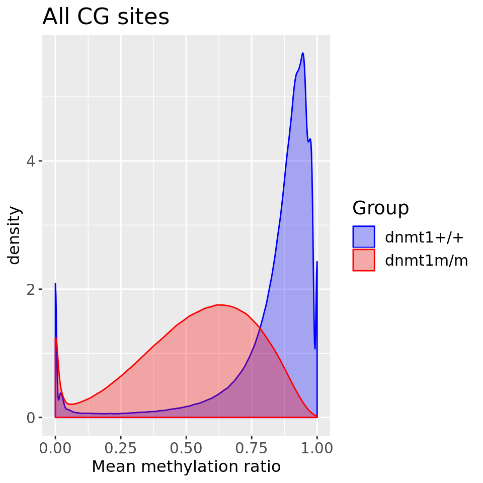

Figure 1e. Mean methylation ratio density in zebrafish larvae.

```r
limdat.CC.MeansL$Group <- as.character(limdat.CC.MeansL$Group)
limdat.CC.MeansL$Group[limdat.CC.MeansL$Group %in% "MT"] <- "dnmt1m/m"
limdat.CC.MeansL$Group[limdat.CC.MeansL$Group %in% "WT"] <- "dnmt1+/+"
limdat.CC.MeansL$Group <- factor(limdat.CC.MeansL$Group, levels = c("dnmt1+/+",
    "dnmt1m/m"))
ggplot(data = limdat.CC.MeansL, aes(x = Beta.Mean)) + geom_density(aes(group = Group,
    colour = Group, fill = Group), alpha = 0.3) + ggtitle("All CG sites") +
    theme(text = element_text(size = 14), axis.text = element_text(size = 11),
        axis.title = element_text(size = 12)) + xlab("Mean methylation ratio") +
    scale_colour_manual(values = c("blue", "red")) + scale_fill_manual(values = c("blue",
    "red"))
```

The density plot reveals a global hypomethylation of genomic CpG sites in dnmt1 mutant fish larvae.

#### Figure 1f: CpG Methylation ratio density in wildtype and mutant zebrafish sperm

Load the zebrafish sperm methylation matrix containing NA values masking cytosines with coverage below 10 reads and/or SNP frequency at least 0.25 for main chromosomes:

```r
con <- curl("https://owncloud.gwdg.de/index.php/s/rnhnQNXbsT6MyuK/download",
    open = "rb")
load(con)
close(con)

dim(limdat)
```

```
## [1] 23946533        7
```

```r
sum(is.na(limdat))
```

```
## [1] 62387904
```

```r
## limdat is in a data.table format - make sure the data.table package is
## loaded!
limdat
```

```
##                      ms Lib_A215_1 Lib_A215_2 Lib_A215_3 Lib_A215_4
##        1:       chr1_81         NA  1.0000000      1.000  0.6842105
##        2:       chr1_92         NA  0.9333333         NA  0.7647059
##        3:      chr1_149         NA  0.9473684      1.000  1.0000000
##        4:      chr1_234  0.5625000  0.7894737      0.625  0.1538462
##        5:      chr1_317  0.9090909  0.9411765      0.875  0.3333333
##       ---
## 23946529: chr9_56892470         NA  1.0000000         NA         NA
## 23946530: chr9_56892537  1.0000000  1.0000000      1.000         NA
## 23946531: chr9_56892580         NA         NA      1.000         NA
## 23946532: chr9_56892709         NA         NA         NA         NA
## 23946533: chr9_56892715         NA         NA         NA         NA
##           Lib_A215_5 Lib_A215_6
##        1:  1.0000000  0.7857143
##        2:  0.8461538  0.7857143
##        3:         NA  0.8333333
##        4:  0.3888889  0.5000000
##        5:         NA  0.5000000
##       ---
## 23946529:  0.4500000  0.8666667
## 23946530:  1.0000000  1.0000000
## 23946531:  1.0000000  1.0000000
## 23946532:         NA         NA
## 23946533:         NA         NA
```

For single CpG analysis, retain CpG positions with support from all replicates:

```r
limdat.CC <- limdat[complete.cases(limdat), ]
colnames(limdat.CC)[2:ncol(limdat.CC)] <- c("WT1", "WT2", "WT3", "MT1", "MT2",
    "MT3")

dim(limdat.CC)
```

```
## [1] 7339075       7
```

```r
sum(is.na(limdat.CC))
```

```
## [1] 0
```

We would like to profile genome-wide CpG methylation ratio distributions in groups of dnmt1 wildtype and mutant fish sperm. We compute group mean methylation ratios per CpG position:

```r
limdat.CC.Means <- data.frame(rowMeans(limdat.CC[, grep("MT", colnames(limdat.CC)),
    with = FALSE]))
colnames(limdat.CC.Means) <- "MT"
limdat.CC.Means$WT <- rowMeans(limdat.CC[, grep("WT", colnames(limdat.CC)),
    with = FALSE])

rownames(limdat.CC.Means) <- limdat.CC$ms
head(limdat.CC.Means)
```

```
##                  MT        WT
## chr1_234  0.3475783 0.6589912
## chr1_1415 0.4296935 0.6312169
## chr1_1447 0.7373703 0.8533769
## chr1_1904 0.7985348 0.9277778
## chr1_2841 0.4425926 1.0000000
## chr1_3029 0.4113712 0.8568207
```

Transform data to long table format with reshape2 and generate the density plot with ggplot2:

```r
limdat.CC.MeansL <- melt(limdat.CC.Means, variable.name = "Group", value.name = "Beta.Mean")
```

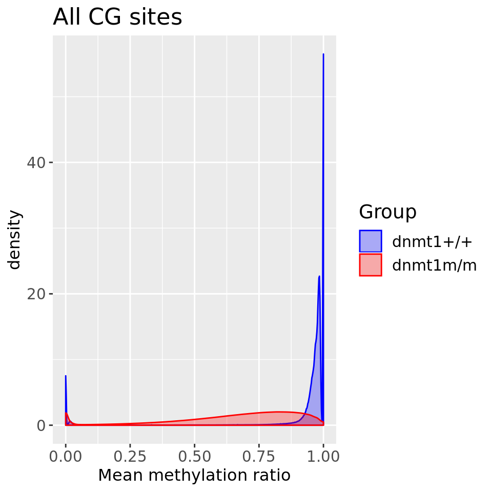

Figure 1f. Mean methylation ratio density in zebrafish sperm.

```r
limdat.CC.MeansL$Group <- as.character(limdat.CC.MeansL$Group)
limdat.CC.MeansL$Group[limdat.CC.MeansL$Group %in% "MT"] <- "dnmt1m/m"
limdat.CC.MeansL$Group[limdat.CC.MeansL$Group %in% "WT"] <- "dnmt1+/+"
limdat.CC.MeansL$Group <- factor(limdat.CC.MeansL$Group, levels = c("dnmt1+/+",
    "dnmt1m/m"))
ggplot(data = limdat.CC.MeansL, aes(x = Beta.Mean)) + geom_density(aes(group = Group,
    colour = Group, fill = Group), alpha = 0.3) + ggtitle("All CG sites") +
    theme(text = element_text(size = 14), axis.text = element_text(size = 11),
        axis.title = element_text(size = 12)) + xlab("Mean methylation ratio") +
    scale_colour_manual(values = c("blue", "red")) + scale_fill_manual(values = c("blue",
    "red"))
```

The density plot reveals a global hypomethylation of genomic CpG sites in dnmt1 mutant fish sperm.

#### Figure 6a left panel: CpG Violin plot of methylation ratio in wildtype and mutant G2 zebrafish sperm.

Replot Figure 1F as violin plot.

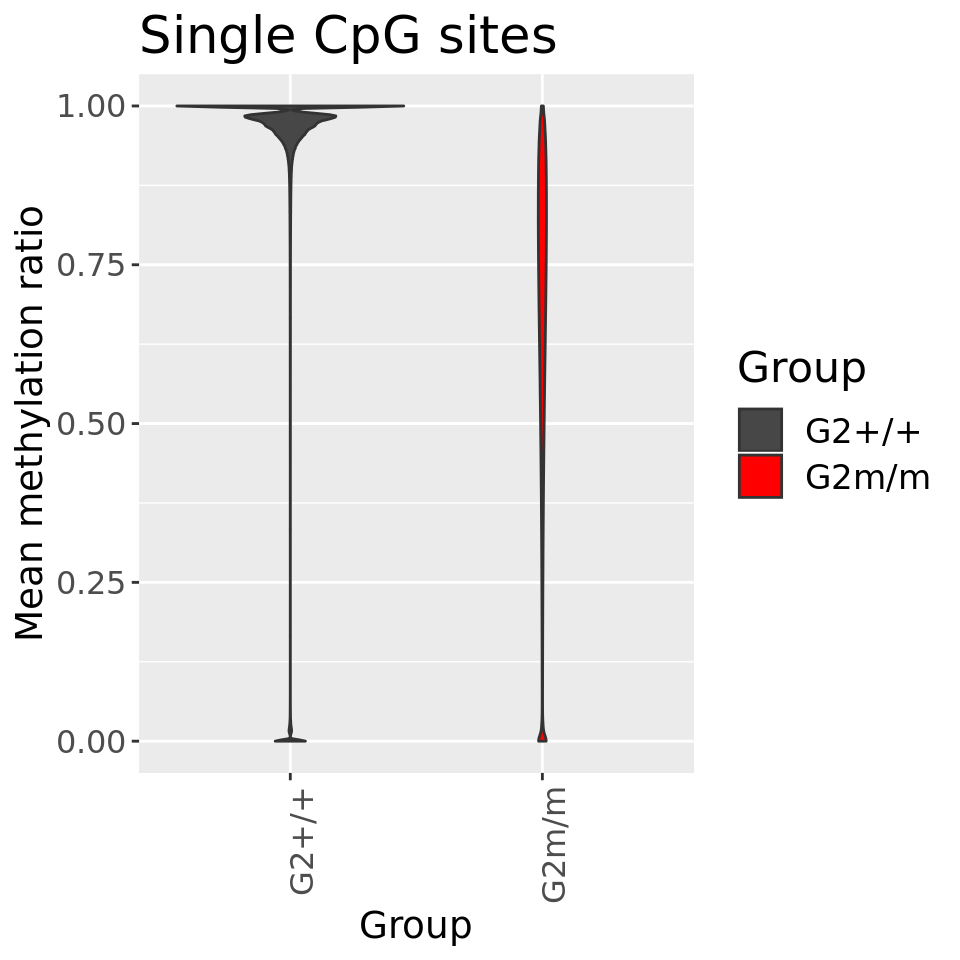

Figure 6a left panel: CpG Violin plot of methylation ratio in wildtype and mutant G2 zebrafish sperm.

```r
limdat.CC.MeansL$Group <- as.character(limdat.CC.MeansL$Group)
limdat.CC.MeansL$Group[limdat.CC.MeansL$Group %in% "dnmt1m/m"] <- "G2m/m"
limdat.CC.MeansL$Group[limdat.CC.MeansL$Group %in% "dnmt1+/+"] <- "G2+/+"
limdat.CC.MeansL$Group <- factor(limdat.CC.MeansL$Group, levels = c("G2+/+",
    "G2m/m"))
ggplot(data = limdat.CC.MeansL) + geom_violin(aes(x = Group, y = Beta.Mean,
    fill = Group)) + ggtitle("Single CpG sites") + theme(text = element_text(size = 16),
    axis.text = element_text(size = 12), axis.title = element_text(size = 14),
    axis.text.x = element_text(angle = 90, hjust = 1)) + ylab("Mean methylation ratio") +
    scale_fill_manual(values = c("grey28", "red", "darkblue", "darkgreen"))
```

The violin plot reveals a global hypomethylation of genomic CpG sites in dnmt1 mutant fish sperm.

#### Figure 6a right panel: CpG Violin plot of methylation ratio in normal and affected G4 zebrafish sperm.

Load the zebrafish sperm methylation matrix containing NA values masking cytosines with coverage below 10 reads and/or SNP frequency at least 0.25 for main chromosomes:

```r
con <- curl("https://owncloud.gwdg.de/index.php/s/yBqvW1OFSA57lC9/download",
    open = "rb")
load(con)
close(con)

dim(limdat)
```

```
## [1] 23946533        7
```

```r
sum(is.na(limdat))
```

```
## [1] 53387405
```

```r
## limdat is in a data.table format - make sure the data.table package is
## loaded!
limdat
```

```
##                      ms      10s       11s        1s        4s        5s
##        1:       chr1_81 1.000000 1.0000000 1.0000000 1.0000000 0.9629630
##        2:       chr1_92 0.952381        NA 0.8636364 0.7500000 0.8076923
##        3:      chr1_149 1.000000 1.0000000 0.8333333 1.0000000 0.9259259
##        4:      chr1_234       NA 0.6428571 0.6428571 0.7777778 0.7200000
##        5:      chr1_317 0.437500 1.0000000 0.6666667 0.8571429 0.9166667
##       ---
## 23946529: chr9_56892470 1.000000 1.0000000 0.9444444 0.9500000 0.9444444
## 23946530: chr9_56892537 1.000000 1.0000000 0.9600000 1.0000000 0.9230769
## 23946531: chr9_56892580 1.000000 1.0000000 0.8125000        NA 1.0000000
## 23946532: chr9_56892709       NA 1.0000000 0.9090909        NA 1.0000000
## 23946533: chr9_56892715       NA 1.0000000 1.0000000        NA        NA
##                  6s
##        1: 1.0000000
##        2: 0.8823529
##        3: 0.9411765
##        4: 0.6829268
##        5: 0.9642857
##       ---
## 23946529: 1.0000000
## 23946530: 0.9130435
## 23946531: 0.9285714
## 23946532: 1.0000000
## 23946533: 1.0000000
```

For single CpG analysis, retain CpG positions with support from all replicates:

```r
limdat.CC <- limdat[complete.cases(limdat), ]

colnames(limdat.CC)[match(c("5s", "6s", "10s"), colnames(limdat.CC))] <- c("Ctrl1",
    "Ctrl2", "Ctrl3")
colnames(limdat.CC)[match(c("1s", "4s", "11s"), colnames(limdat.CC))] <- c("Pb1",
    "Pb2", "Pb3")

dim(limdat.CC)
```

```
## [1] 9521488       7
```

```r
sum(is.na(limdat.CC))
```

```
## [1] 0
```

We would like to profile genome-wide CpG methylation ratio distributions in groups of normal and affected G4 fish sperm. We compute group mean methylation ratios per CpG position:

```r
limdat.CC.Means <- data.frame(rowMeans(limdat.CC[, grep("Pb", colnames(limdat.CC)),
    with = FALSE]))
colnames(limdat.CC.Means) <- "Pb"
limdat.CC.Means$Ctrl <- rowMeans(limdat.CC[, grep("Ctrl", colnames(limdat.CC)),
    with = FALSE])

rownames(limdat.CC.Means) <- limdat.CC$ms
head(limdat.CC.Means)
```

```
##                 Pb      Ctrl
## chr1_81  1.0000000 0.9876543
## chr1_149 0.9444444 0.9557008
## chr1_317 0.8412698 0.7728175
## chr1_374 0.6588694 0.8518519
## chr1_787 0.7698413 0.5952381
## chr1_918 0.8070175 0.8603006
```

Transform data to long table format with reshape2 and generate the violin plot with ggplot2:

```r
limdat.CC.MeansL <- melt(limdat.CC.Means, variable.name = "Group", value.name = "Beta.Mean")
```

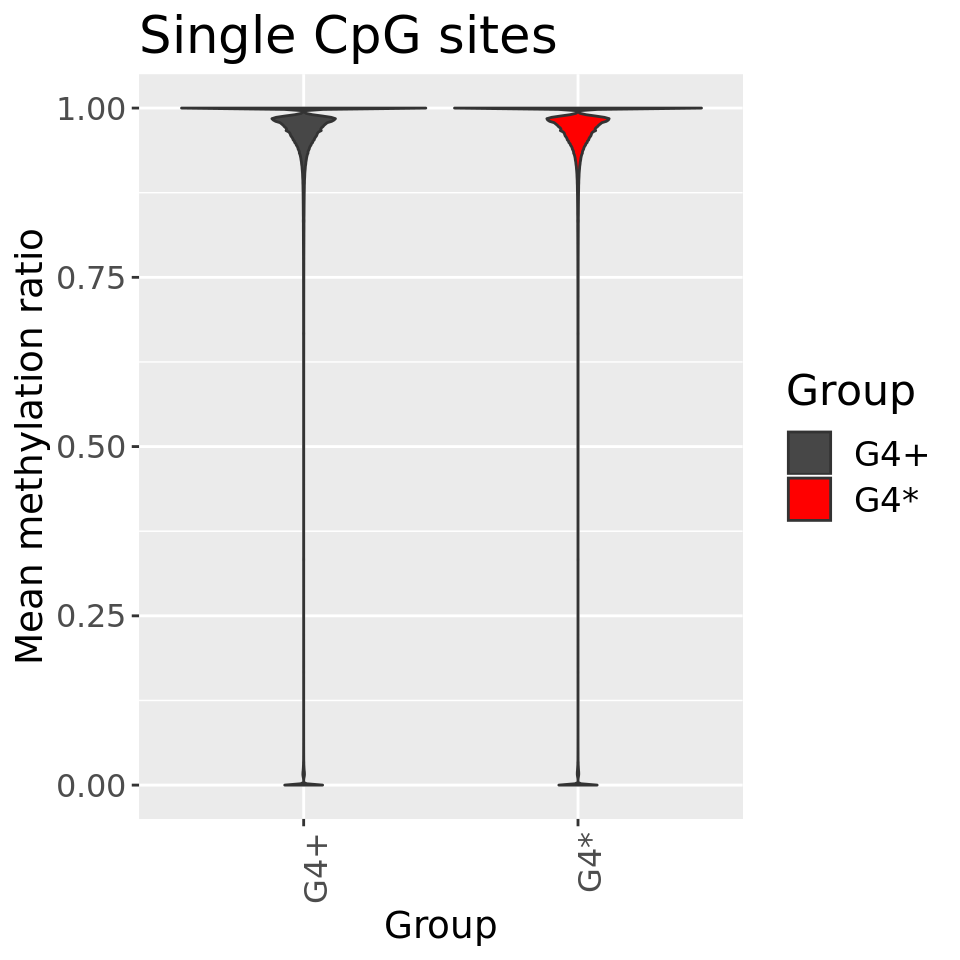

Figure 6a right panel. Violin plot of mean methylation ratio in zebrafish G4 sperm.

```r
limdat.CC.MeansL$Group <- as.character(limdat.CC.MeansL$Group)
limdat.CC.MeansL$Group[limdat.CC.MeansL$Group %in% "Pb"] <- "G4*"
limdat.CC.MeansL$Group[limdat.CC.MeansL$Group %in% "Ctrl"] <- "G4+"
limdat.CC.MeansL$Group <- factor(limdat.CC.MeansL$Group, levels = c("G4+", "G4*"))

ggplot(data = limdat.CC.MeansL) + geom_violin(aes(x = Group, y = Beta.Mean,
    fill = Group)) + ggtitle("Single CpG sites") + theme(text = element_text(size = 16),
    axis.text = element_text(size = 12), axis.title = element_text(size = 14),
    axis.text.x = element_text(angle = 90, hjust = 1)) + ylab("Mean methylation ratio") +
    scale_fill_manual(values = c("grey28", "red", "darkblue", "darkgreen"))
```

The violin plot of global genomic CpG site methylation reveals no apparent differences between G4+ and G4* fish sperm.

#### Figure 6b: Evaluation of G4 zebrafish sperm DMRs in G2 zebrafish sperm.

Load results of statistical evaluation of G4 sperm candidate DMRs split by their change direction in G2 sperm:

```r
# con <-
# curl('https://owncloud.gwdg.de/index.php/s/sHTiST0yjvMEXv6/download',open='rb')
# load(con) close(con)

# unch<-tT unch$G2<-'Unchanged/NS'
# unch$G2[unch$adj.P.Val<0.02&unch$Diff<=(-0.2)]<-'Hypo'
# unch$G2[unch$adj.P.Val<0.02&unch$Diff>=(0.2)]<-'Hyper'
# unch$G4<-'Unchanged/NS'

con <- curl("https://owncloud.gwdg.de/index.php/s/IC1SivxF5Kh3xmH/download",
    open = "rb")
load(con)
close(con)

hypo <- tT
hypo$G2 <- "Unchanged/NS"
hypo$G2[hypo$adj.P.Val < 0.02 & hypo$Diff <= (-0.2)] <- "Hypo"
hypo$G2[hypo$adj.P.Val < 0.02 & hypo$Diff >= (0.2)] <- "Hyper"
hypo$G4 <- "Hypo"

con <- curl("https://owncloud.gwdg.de/index.php/s/gKeTusEW2RphUII/download",
    open = "rb")
load(con)
close(con)

hyper <- tT
hyper$G2 <- "Unchanged/NS"
hyper$G2[hyper$adj.P.Val < 0.02 & hyper$Diff <= (-0.2)] <- "Hypo"
hyper$G2[hyper$adj.P.Val < 0.02 & hyper$Diff >= (0.2)] <- "Hyper"
hyper$G4 <- "Hyper"

all <- as.data.frame(rbind(hypo, hyper), stringsAsFactors = FALSE)  #unch,

table(all$G4, all$G2)
```

```
##
##         Hypo Unchanged/NS
##   Hyper   17           58
##   Hypo   101           61
```

Prepare data for plotting with ggalluvial.

```r
plotdat <- summarize(group_by(all, G2, G4), Freq = n())
# plotdat2<-filter(plotdat,!G4=='Unchanged/NS')
plotdat2 <- filter(plotdat, !G2 == "Hyper")
plotdat2
```

```
## # A tibble: 4 x 3
## # Groups:   G2 [2]
##   G2           G4     Freq
##   <chr>        <chr> <int>
## 1 Hypo         Hyper    17
## 2 Hypo         Hypo    101
## 3 Unchanged/NS Hyper    58
## 4 Unchanged/NS Hypo     61
```

```r
is_alluvia_form(plotdat2)
```

```
## Missing alluvia for some stratum combinations.
```

```
## [1] TRUE
```

```r
plotdat2 <- as.data.frame(plotdat2, stringsAsFactors = FALSE)
plotdat2$Direction <- "Remethylated to WT"
plotdat2$Direction[plotdat2$G2 %in% "Hypo" & plotdat2$G4 %in% "Hyper"] <- "Overcompensated"
plotdat2$Direction[plotdat2$G2 %in% "Hyper" & plotdat2$G4 %in% "Hyper"] <- "Remnant"
plotdat2$Direction[plotdat2$G2 %in% "Hypo" & plotdat2$G4 %in% "Hypo"] <- "Remnant"
plotdat2$Direction[plotdat2$G2 %in% "Unchanged/NS" & plotdat2$G4 %in% "Hyper"] <- "DeNovoMethylated"
plotdat2$Direction[plotdat2$G2 %in% "Unchanged/NS" & plotdat2$G4 %in% "Hypo"] <- "DeNovoDemethylated"
plotdat2
```

```
##             G2    G4 Freq          Direction
## 1         Hypo Hyper   17    Overcompensated
## 2         Hypo  Hypo  101            Remnant
## 3 Unchanged/NS Hyper   58   DeNovoMethylated
## 4 Unchanged/NS  Hypo   61 DeNovoDemethylated
```

Plot data.

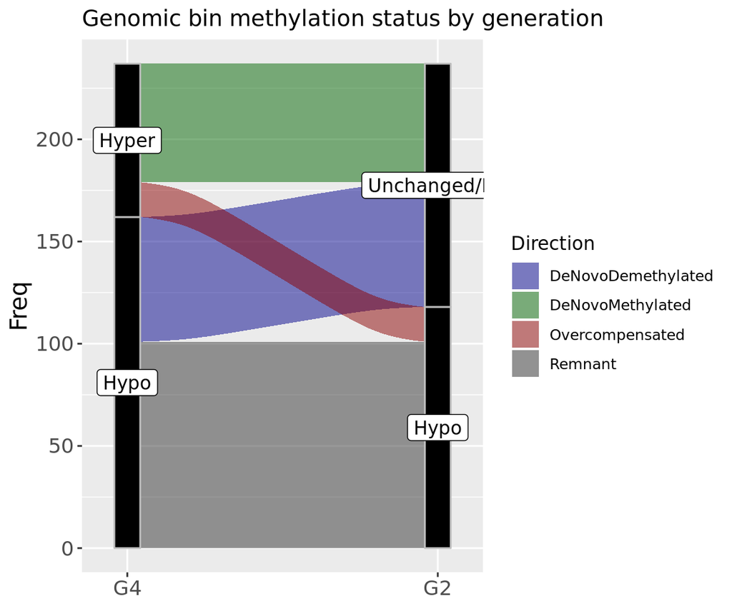

Figure 6b. Alluvial plot of G4 sperm DMR re-evaluation in G2 sperm data.

```r
plotdat2$G2<-factor(plotdat2$G2,levels=c("Unchanged/NS","Hypo"))
plotdat2$G4<-factor(plotdat2$G4,levels=c("Hypo","Hyper"))
ggplot(plotdat2,
       aes(y = Freq, axis1 = G4, axis2 = G2)) +
  geom_alluvium(aes(fill=Direction),width = 1/12,reverse=FALSE) + #geom_stratum(,reverse=FALSE) +
  stat_stratum(reverse = FALSE,width = 1/12, fill = "black", color = "grey")+
  geom_label(stat = "stratum", infer.label = TRUE,reverse=FALSE) +
  scale_x_discrete(limits = c("G4", "G2"), expand = c(.05, .05)) +
  scale_fill_manual(values=c("darkblue","darkgreen","darkred","grey20")) +
  ggtitle("Genomic bin methylation status by generation")+theme(axis.text=element_text(size=12),axis.title=element_text(size=14))
```

#### Figure 6c-d: Chromosome-wise numbers of de-novo DMRs in G4 zebrafish sperm.

Read in tables with hypo- and hypermethylated DMRs:

```r
con <- curl("https://owncloud.gwdg.de/index.php/s/IllgF5WJh6nQbWj/download",
    open = "r")
hypo <- read.table(con, header = TRUE, as.is = TRUE, sep = "\t", quote = "")
close(con)

head(hypo)
```

```
##   Row.names     logFC          t  adj.P.Val        B  Ctrlmean      Pbmean
## 1       307 -3.693722 -10.274048 0.01254894 2.940679 0.5450630 0.004089534
## 2       317 -3.650017  -9.636417 0.01254894 2.621977 0.5300530 0.003993719
## 3      2127 -3.788377  -9.523176 0.01254894 2.562265 0.5535150 0.002270723
## 4       319 -3.657719  -9.417846 0.01254894 2.505840 0.5974354 0.012934459
## 5      2930 -3.346183  -9.311379 0.01254894 2.447924 0.4645677 0.005245446
## 6       308 -3.292876  -9.139402 0.01254894 2.352454 0.4992677 0.011625674
##     Chr    Start     Stop  qvalue MeanDiff NumCpGs    pMWU   p2DKS
## 1 chr10 18031128 18031732 2.5e-09 0.546992      14 4.7e-14 1.2e-15
## 2 chr10 21163879 21164582 2.9e-12 0.530435      18 4.0e-14 1.4e-18
## 3 chr24    40280    40902 2.3e-10 0.544177      16 4.3e-14 1.1e-16
## 4 chr10 21606421 21607829 2.9e-10 0.575965      18 4.1e-14 1.4e-16
## 5  chr6 42951932 42952497 3.0e-12 0.457271      19 4.1e-14 1.4e-18
## 6 chr10 19038991 19039914 9.0e-12 0.493747      17 4.4e-14 4.3e-18
##   meanCtrl    meanPb N.CG.NA N.CG.tot CGI.NAf            ENSDARG
```

[output cut: 27 more lines]

```r
con <- curl("https://owncloud.gwdg.de/index.php/s/sycC2qgeLFWsGsL/download",
    open = "r")
hyper <- read.table(con, header = TRUE, as.is = TRUE, sep = "\t", quote = "")
close(con)

head(hyper)
```

```
##   Row.names    logFC         t  adj.P.Val        B    Ctrlmean    Pbmean
## 1       980 4.122919 10.462231 0.01254894 3.029346 0.002637320 0.6392668
## 2      1061 3.726487 10.428567 0.01254894 3.013657 0.012855339 0.6217750
## 3      3624 4.078841 10.266971 0.01254894 2.937298 0.004502782 0.6426169
## 4      1000 3.581481 10.030030 0.01254894 2.822127 0.007543205 0.5455898
## 5      1063 3.526854  9.624360 0.01254894 2.615666 0.012885348 0.5697710
## 6      2829 3.289286  9.284673 0.01254894 2.433255 0.440518290 0.9792380
##     Chr    Start     Stop  qvalue  MeanDiff NumCpGs    pMWU   p2DKS
## 1 chr16 24451372 24451759 1.1e-17 -0.641198      23 4.6e-14 5.3e-24
## 2 chr16 42257396 42258613 6.7e-22 -0.573465      30 4.7e-14 3.2e-28
## 3  chr9 31535864 31536433 1.2e-04 -0.585535      10 2.9e-11 5.5e-11
## 4 chr16 28694682 28695031 4.0e-08 -0.509907      14 4.7e-14 1.9e-14
## 5 chr16 42491311 42491656 3.1e-03 -0.517454      10 2.9e-11 1.5e-09
## 6  chr6 26879951 26880455 3.9e-05 -0.574967      11 2.9e-12 1.9e-11
##    meanCtrl  meanPb N.CG.NA N.CG.tot CGI.NAf            ENSDARG
```

[output cut: 27 more lines]

Select unique DMRs for both tables:

```r
hypo$ms <- with(hypo, paste0(Chr, "_", Start, "_", Stop))
hypo.sub <- subset(hypo, select = c("Chr", "Start", "Stop", "ms"))
hypoU <- unique(hypo.sub)
nrow(hypoU)
```

```
## [1] 164
```

```r
hyper$ms <- with(hyper, paste0(Chr, "_", Start, "_", Stop))
hyper.sub <- subset(hyper, select = c("Chr", "Start", "Stop", "ms"))
hyperU <- unique(hyper.sub)
nrow(hyperU)
```

```
## [1] 79
```

Prepare data for plotting:

```r
hypoU$EventsXChrom <- ave(hypoU$Chr, hypoU$Chr, FUN = length)
hyperU$EventsXChrom <- ave(hyperU$Chr, hyperU$Chr, FUN = length)
hypoU$Direction <- "Hypo"
hyperU$Direction <- "Hyper"
hypoX <- unique(subset(hypoU, select = c("Chr", "EventsXChrom", "Direction")))
hyperX <- unique(subset(hyperU, select = c("Chr", "EventsXChrom", "Direction")))

plotdat <- data.frame(Chr = paste0("chr", 1:25))
hypoY <- merge(x = plotdat, y = hypoX, by = "Chr", all.x = TRUE)
hyperY <- merge(x = plotdat, y = hyperX, by = "Chr", all.x = TRUE)
plotdat2 <- as.data.frame(rbind(hypoY, hyperY), stringsAsFactors = FALSE)
plotdat2$Direction <- rep(c("hypomethylation", "hypermethylation"), each = 25)
plotdat2$EventsXChrom[is.na(plotdat2$EventsXChrom)] <- 0
plotdat2$Chr <- factor(plotdat2$Chr, levels = paste0("chr", 1:25))
plotdat2$EventsXChrom <- as.numeric(plotdat2$EventsXChrom)

head(plotdat2)
```

```
##     Chr EventsXChrom       Direction
## 1  chr1            2 hypomethylation
## 2 chr10           12 hypomethylation
## 3 chr11            0 hypomethylation
## 4 chr12            0 hypomethylation
## 5 chr13            2 hypomethylation
## 6 chr14            0 hypomethylation
```

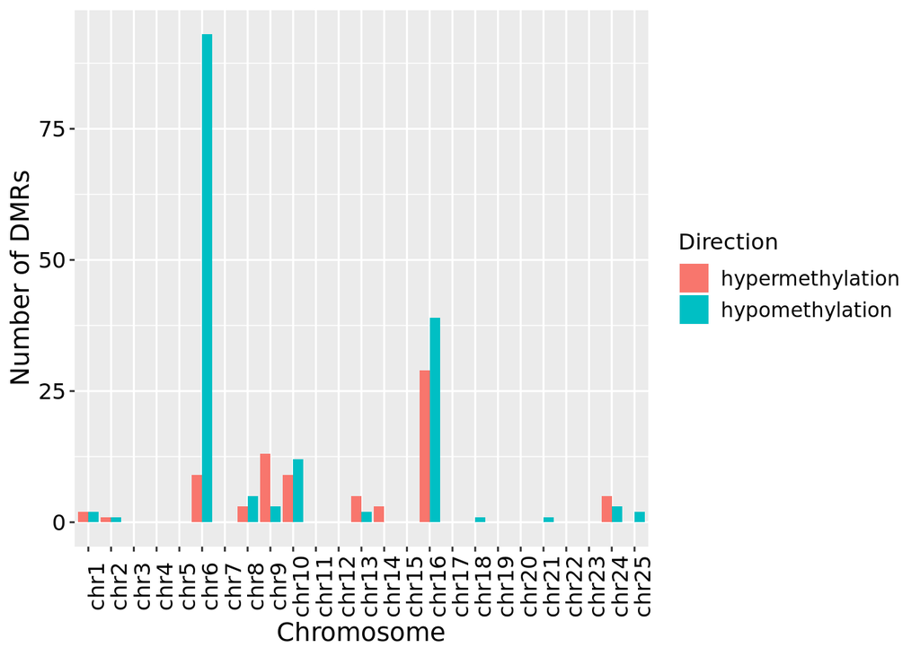

Figure 6c. Number of hypo- and hypermethylated DMRs per chromosome in G4 zebrafish sperm.

```r
ggplot(data = plotdat2) + geom_bar(aes(x = Chr, y = EventsXChrom, group = Direction,
    fill = Direction), stat = "identity", position = position_dodge()) + ylab("Number of DMRs") +
    xlab("Chromosome") + theme(axis.text.y = element_text(size = 12, color = "black"),
    axis.text.x = element_text(size = 12, color = "black", angle = 90), axis.title = element_text(size = 14,
        color = "black"), legend.text = element_text(size = 11, color = "black"),
    legend.title = element_text(size = 12, color = "black"))
```

Chromosomes 16, 6, 9, and 10 have an apparently increased number of DMRs.  
We plot the single DMRs per chromosome as well as their methylation difference between the G4+ and G4* groups.

```r
chr_choice <- c("chr6", "chr9", "chr10", "chr16")


DMRhypo.GR <- unique(GRanges(seqnames = hypo$Chr, ranges = IRanges(start = as.numeric(hypo$Start),
    end = as.numeric(hypo$Stop)), strand = "*", MeanDiff = -(hypo$MeanDiff)))
DMRhyper.GR <- GRanges(seqnames = hyper$Chr, ranges = IRanges(start = as.numeric(hyper$Start),
    end = as.numeric(hyper$Stop)), strand = "*", MeanDiff = -(hyper$MeanDiff))
DMRcomb.GR <- c(DMRhypo.GR, DMRhyper.GR)
```

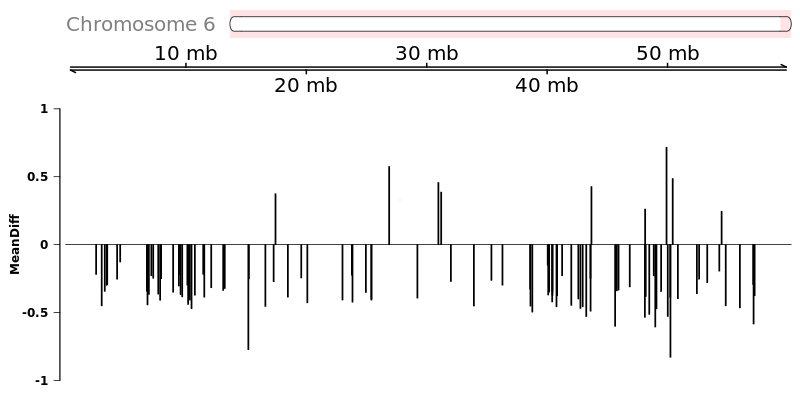

Figure 6d: DMRs on chromosome chr6 in G4 zebrafish sperm.

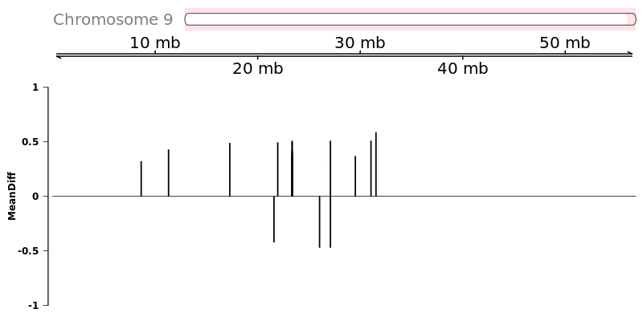

Figure 6d: DMRs on chromosome chr9 in G4 zebrafish sperm.

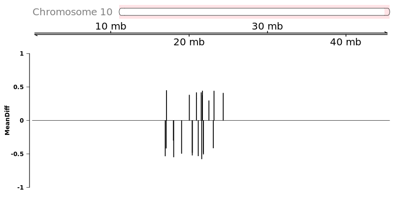

Figure 6d: DMRs on chromosome chr10 in G4 zebrafish sperm.

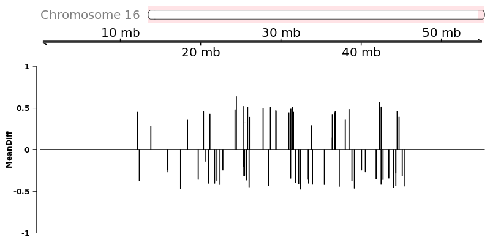

Figure 6d: DMRs on chromosome chr16 in G4 zebrafish sperm.

```r
for (i in seq_along(chr_choice)) {
    chrI <- chr_choice[i]
    ideoTrack <- IdeogramTrack(genome = "danRer10", chromosome = chrI)
    displayPars(ideoTrack) <- list(showTitle = FALSE, col = "transparent", showAxis = FALSE)
    gtrack <- GenomeAxisTrack(seqnames = chrI, from = 1, to = seqlengths(Drerio)[names(seqlengths(Drerio)) %in%
        chrI])
    displayPars(gtrack) <- list(col = "black", fontcolor = "black")
    dtrack <- DataTrack(DMRcomb.GR, name = "MeanDiff", type = "histogram", size = 0.3)  #,groups=rep(c('Hypo','Hyper'),c(length(DMRhypo.GR),length(DMRhyper.GR)))
    displayPars(dtrack) <- list(cex.legend = 1, col.histogram = "black", fill.histogram = "black",
        ylim = c(-1, 1), background.title = "white", fontcolor.title = "black",
        col.axis = "black", baseline = 0, col.baseline = "black", cex.axis = 1,
        cex.title = 1)
    png(paste0("A637.metilene.", chrI, ".Gviz.png"), width = 800, height = 400)
    plotTracks(list(ideoTrack, gtrack, dtrack), cex = 2, chromosome = chrI,
        from = 1, to = seqlengths(Drerio)[names(seqlengths(Drerio)) %in% chrI])
    dev.off()
}
knitr::include_graphics(paste0("A637.metilene.", chr_choice, ".Gviz.png"))
```

#### Figure 7b: Methylation ratio of runx3 and rptor DMRs in wildtype and mutant G4 zebrafish sperm.

Load the G4 zebrafish sperm DMR methylation matrix:

```r
con <- curl("https://owncloud.gwdg.de/index.php/s/SwxeMrLXVXz43Jq/download",
    open = "rb")
load(con)
close(con)

colnames(limdat.LG.CC)[match(c("5s", "6s", "10s"), colnames(limdat.LG.CC))] <- c("Ctrl1",
    "Ctrl2", "Ctrl3")
colnames(limdat.LG.CC)[match(c("1s", "4s", "11s"), colnames(limdat.LG.CC))] <- c("Pb1",
    "Pb2", "Pb3")

dim(limdat.LG.CC)
```

```
## [1] 3664    6
```

```r
sum(is.na(limdat.LG.CC))
```

```
## [1] 0
```

```r
head(limdat.LG.CC)
```

```
##        Ctrl3       Pb3        Pb1       Pb2     Ctrl1     Ctrl2
## 1 0.32548368 0.9915022 0.55117297 0.4236141 0.9554564 0.3972301
## 2 0.57809838 0.9244048 0.73972489 0.8434366 0.5483417 0.9372485
## 3 0.66228338 0.9163156 0.60138213 0.5117658 0.7352318 0.9182822
## 4 0.08717949 0.4550013 0.03631933 0.0000000 0.5339757 0.4895292
## 5 0.75884454 0.6256061 0.99187500 0.9072648 0.5996819 0.7342650
## 6 0.96730965 0.7130791 0.76474447 0.8376061 0.7550736 0.9536199
```

We identify the rows of topTable containing differential DMR methylation results for genes ‘runx3’ and ‘rptor’:

```r
con <- curl("https://owncloud.gwdg.de/index.php/s/aPaBBsfTQ9Mh72U/download",
    open = "r")
tT <- read.table(con, header = TRUE, as.is = TRUE, sep = "\t", quote = "")
close(con)

tT[tT$GeneSymbol %in% c("runx3", "rptor"), ]
```

```
##     Row.names    logFC        t  adj.P.Val         B  Ctrlmean    Pbmean
## 96       2774 2.399581 6.714449 0.01473125 0.7095506 0.5860846 0.9618150
## 111       662 2.385562 6.371922 0.01724146 0.4244537 0.6413146 0.9725951
##       Chr    Start     Stop  qvalue  MeanDiff NumCpGs    pMWU p2DKS
## 96   chr6 17437580 17439602 1.9e-32 -0.374355      47 4.1e-14 9e-39
## 111 chr13 44953072 44953566 2.1e-10 -0.340390      18 4.4e-14 1e-16
##     meanCtrl  meanPb N.CG.NA N.CG.tot CGI.NAf            ENSDARG
## 96   0.58631 0.96067       3       55       1 ENSDARG00000098726
## 111  0.63577 0.97616       1       20       1 ENSDARG00000052826
##     GeneSymbol
## 96       rptor
## 111      runx3
##                                                                                Description
## 96  regulatory associated protein of MTOR, complex 1 [Source:ZFIN;Acc:ZDB-GENE-130530-685]
## 111                runt-related transcription factor 3 [Source:ZFIN;Acc:ZDB-GENE-000605-2]
##           Diff Dist
## 96  -0.3757304    0
## 111 -0.3312806 2296
```

We fetch the DMR methylation values using the ‘Row.names’ column in topTable identified in the previous step:

```r
runx3 <- limdat.LG.CC[662, ]
rptor <- limdat.LG.CC[2774, ]

d <- as.data.frame(t(rbind(runx3, rptor)))
colnames(d) <- c("runx3", "rptor")
d$SampleID <- rownames(d)
d$Group <- "G4+"
d$Group[grep("Pb", d$SampleID)] <- "G4*"


plotdat <- melt(d, id.vars = c("SampleID", "Group"), variable.name = "Locus",
    value.name = "MethylationRatio")
plotdat
```

```
##    SampleID Group Locus MethylationRatio
## 1     Ctrl3   G4+ runx3        0.6887099
## 2       Pb3   G4* runx3        0.9844786
## 3       Pb1   G4* runx3        0.9613682
## 4       Pb2   G4* runx3        0.9719386
## 5     Ctrl1   G4+ runx3        0.6102330
## 6     Ctrl2   G4+ runx3        0.6250008
## 7     Ctrl3   G4+ rptor        0.6207475
## 8       Pb3   G4* rptor        0.9662392
## 9       Pb1   G4* rptor        0.9617457
## 10      Pb2   G4* rptor        0.9574601
## 11    Ctrl1   G4+ rptor        0.5865205
## 12    Ctrl2   G4+ rptor        0.5509858
```

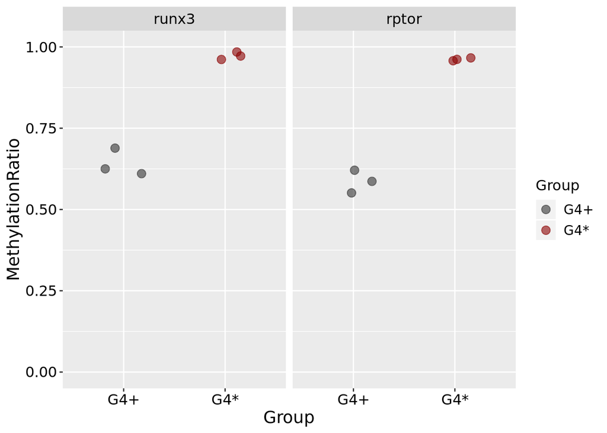

Figure 7b. Per replicate DMR methylation ratio in G4 zebrafish sperm for selected regions.

```r
plotdat$Group <- factor(plotdat$Group, levels = c("G4+", "G4*"))
ggplot(plotdat) + geom_point(aes(x = Group, y = MethylationRatio, group = Group,
    colour = Group), size = 3, alpha = 0.6, position = position_jitter(width = 0.2,
    height = 0, seed = 123)) + facet_grid(~Locus) + scale_colour_manual(values = c("grey20",
    "darkred")) + ylim(c(0, 1)) + theme(axis.text = element_text(size = 12,
    color = "black"), axis.title = element_text(size = 14, color = "black"),
    legend.text = element_text(size = 11, color = "black"), legend.title = element_text(size = 12,
        color = "black"), strip.text = element_text(size = 12, color = "black"))
```

The plot shows a trend towards hypermethylation of both regions in G4* fish sperm as compared to G4+.

#### Supplementary Figure 2b: Violin plots of gene regulatory region methylation ratios in normal and affected G2 and G4 zebrafish sperm.

Load zebrafish sperm methylation matrices obtained through averaging of CpG methylation values over target regions :

```r
conL <- c("https://owncloud.gwdg.de/index.php/s/xM4iV7c0uBdbYtq/download", "https://owncloud.gwdg.de/index.php/s/mdoY3EjAOJoM32X/download",
    "https://owncloud.gwdg.de/index.php/s/AReo7EfJbRhKIbC/download", "https://owncloud.gwdg.de/index.php/s/uYQ5Yl8587aI2Ng/download",
    "https://owncloud.gwdg.de/index.php/s/ap1hCKnBcZc0CkP/download", "https://owncloud.gwdg.de/index.php/s/tHtigelOj443mnT/download")
nv <- c("CpG_islands", "promoters", "exons", "introns", "intergenic_regions",
    "placeholder_nucleosomal_regions")

limL <- mapply(function(a, b) {
    con <- curl(a, open = "rb")
    load(con)
    close(con)
    limdat.CC <- CGI.limdat.CC[complete.cases(CGI.limdat.CC), ]
    colnames(limdat.CC)[match(c("5s_A", "6s_A", "10s_A"), colnames(limdat.CC))] <- c("G4_Ctrl1",
        "G4_Ctrl2", "G4_Ctrl3")
    colnames(limdat.CC)[match(c("1s_A", "4s_A", "11s_A"), colnames(limdat.CC))] <- c("G4_Pb1",
        "G4_Pb2", "G4_Pb3")
    colnames(limdat.CC)[match(c("Lib_A215_1", "Lib_A215_2", "Lib_A215_3"), colnames(limdat.CC))] <- c("G2_WT1",
        "G2_WT2", "G2_WT3")
    colnames(limdat.CC)[match(c("Lib_A215_4", "Lib_A215_5", "Lib_A215_6"), colnames(limdat.CC))] <- c("G2_Mut1",
        "G2_Mut2", "G2_Mut3")
    limdat.CC$Region <- b
    rownames(limdat.CC) <- limdat.CC$IntID
    return(limdat.CC)
}, conL, nv, SIMPLIFY = FALSE)

names(limL) <- NULL
limdat <- as.data.frame(do.call(rbind, limL), stringsAsFactors = FALSE)
head(limdat)
```

```
##                       G2_WT1      G2_WT2      G2_WT3     G2_Mut1
## chr1_11941_12167 0.002857143 0.007777778 0.005714286 0.000000000
## chr1_18589_18912 0.000000000 0.000000000 0.003684211 0.002307692
## chr1_27716_27974 0.000000000 0.010000000 0.003684211 0.008125000
## chr1_32993_33352 0.943500000 0.973750000 0.984500000 0.861250000
## chr1_39619_39974 0.969696970 0.980909091 0.980909091 0.907575758
## chr1_41255_41569 0.991818182 0.986400000 0.935238095 0.794500000
##                      G2_Mut2     G2_Mut3    G4_Ctrl3  G4_Ctrl1    G4_Ctrl2
## chr1_11941_12167 0.002857143 0.000000000 0.000000000 0.0000000 0.000952381
## chr1_18589_18912 0.000000000 0.006923077 0.006153846 0.0000000 0.004230769
## chr1_27716_27974 0.003043478 0.003684211 0.000000000 0.0000000 0.000000000
## chr1_32993_33352 0.902500000 0.916666667 0.976190476 0.9765000 0.973043478
## chr1_39619_39974 0.940606061 0.940882353 0.976176471 0.9726471 0.984411765
## chr1_41255_41569 0.922500000 0.904444444 0.945172414 0.9732000 0.959333333
##                       G4_Pb1      G4_Pb2      G4_Pb3            IntID
## chr1_11941_12167 0.004285714 0.007692308 0.007222222 chr1_11941_12167
## chr1_18589_18912 0.006315789 0.011250000 0.005000000 chr1_18589_18912
## chr1_27716_27974 0.000000000 0.005263158 0.002631579 chr1_27716_27974
## chr1_32993_33352 0.933333333 0.981052632 0.975263158 chr1_32993_33352
## chr1_39619_39974 0.993529412 0.981764706 0.973823529 chr1_39619_39974
## chr1_41255_41569 0.971600000 0.992400000 0.987600000 chr1_41255_41569
##                       Region
## chr1_11941_12167 CpG_islands
## chr1_18589_18912 CpG_islands
## chr1_27716_27974 CpG_islands
## chr1_32993_33352 CpG_islands
## chr1_39619_39974 CpG_islands
## chr1_41255_41569 CpG_islands
```

We would like to profile target interval CpG methylation ratio distributions in four fish groups. We compute group mean methylation ratios per target region:

```r
limdat.L <- melt(limdat, id.vars = c("IntID", "Region"), value.name = "Beta",
    variable.name = "Sample")
limdat.L$Sample <- as.character(limdat.L$Sample)
limdat.L$Group <- gsub("[1-3]$", "", limdat.L$Sample)
lg <- group_by(limdat.L, IntID, Region, Group)
limdat.CC.MeansL <- summarize(lg, Beta.Mean = mean(Beta))

head(limdat.CC.MeansL)
```

```
## # A tibble: 6 x 4
## # Groups:   IntID, Region [2]
##   IntID                  Region             Group   Beta.Mean
##   <chr>                  <chr>              <chr>       <dbl>
## 1 chr1_0_6407            intergenic_regions G2_Mut      0.507
## 2 chr1_0_6407            intergenic_regions G2_WT       0.779
## 3 chr1_0_6407            intergenic_regions G4_Ctrl     0.786
## 4 chr1_0_6407            intergenic_regions G4_Pb       0.776
## 5 chr1_10000078_10003489 introns            G2_Mut      0.541
## 6 chr1_10000078_10003489 introns            G2_WT       0.940
```

Prepare plotting labels and generate the violin plot with ggplot2:

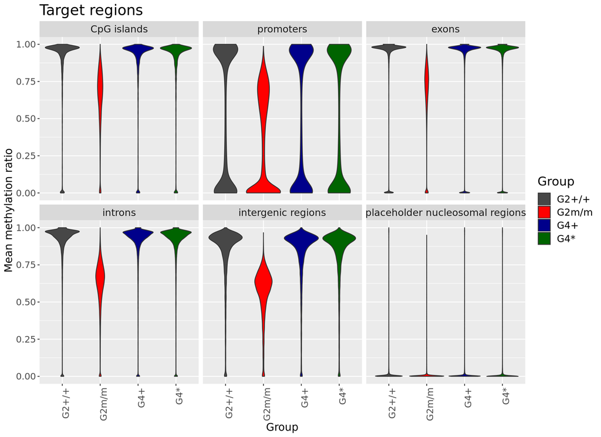

Supplementary Figure 2b. Violin plots of gene regulatory region methylation ratios in normal and affected G2 and G4 zebrafish sperm.

```r
limdat.CC.MeansL <- as.data.frame(limdat.CC.MeansL, stringsAsFactors = FALSE)
limdat.CC.MeansL$Group[limdat.CC.MeansL$Group %in% "G2_WT"] <- "G2+/+"
limdat.CC.MeansL$Group[limdat.CC.MeansL$Group %in% "G2_Mut"] <- "G2m/m"
limdat.CC.MeansL$Group[limdat.CC.MeansL$Group %in% "G4_Pb"] <- "G4*"
limdat.CC.MeansL$Group[limdat.CC.MeansL$Group %in% "G4_Ctrl"] <- "G4+"
limdat.CC.MeansL$Group <- factor(limdat.CC.MeansL$Group, levels = c("G2+/+",
    "G2m/m", "G4+", "G4*"))
limdat.CC.MeansL$Region <- factor(limdat.CC.MeansL$Region, levels = c("CpG_islands",
    "promoters", "exons", "introns", "intergenic_regions", "placeholder_nucleosomal_regions"))
levels(limdat.CC.MeansL$Region) <- gsub("_", " ", levels(limdat.CC.MeansL$Region))

ggplot(data = limdat.CC.MeansL) + geom_violin(aes(x = Group, y = Beta.Mean,
    fill = Group)) + ggtitle("Target regions") + theme(text = element_text(size = 16),
    axis.text = element_text(size = 12), axis.title = element_text(size = 14),
    axis.text.x = element_text(angle = 90, hjust = 1)) + ylab("Mean methylation ratio") +
    scale_fill_manual(values = c("grey28", "red", "darkblue", "darkgreen")) +
    facet_wrap(~Region, nrow = 2)
```

The violin plots show a pronounced hypomethylation of all highly methylated regions in G2m/m fish compared to G2+/+, whereas G4* fish show methylation values undestinguishable from G4+, and G2+/+ fish. Placeholder nucleosomes are mostly unmethylated to start with, and are not further affected by the Dnmt1 methylation defect.

#### Supplementary Figure 2c: Violin plots of zebrafish early development DMR methylation ratios in normal and affected G2 and G4 zebrafish sperm.

Load zebrafish sperm methylation matrices obtained through averaging of CpG methylation values over target regions :

```r
conL <- c("https://owncloud.gwdg.de/index.php/s/SFlvlC2XlBs8ioO/download", "https://owncloud.gwdg.de/index.php/s/5RJ5NKdeGd6zCzT/download",
    "https://owncloud.gwdg.de/index.php/s/o9WDVlqu977sTjF/download", "https://owncloud.gwdg.de/index.php/s/0IbEcVV3SD6K2qo/download")
nv <- c("epiboly_24hpf_increasing", "epiboly_24hpf_decreasing", "24hpf_48hpf_increasing",
    "24hpf_48hpf_decreasing")

limL <- mapply(function(a, b) {
    con <- curl(a, open = "rb")
    load(con)
    close(con)
    limdat.CC <- CGI.limdat.CC[complete.cases(CGI.limdat.CC), ]
    colnames(limdat.CC)[match(c("5s_A", "6s_A", "10s_A"), colnames(limdat.CC))] <- c("G4_Ctrl1",
        "G4_Ctrl2", "G4_Ctrl3")
    colnames(limdat.CC)[match(c("1s_A", "4s_A", "11s_A"), colnames(limdat.CC))] <- c("G4_Pb1",
        "G4_Pb2", "G4_Pb3")
    colnames(limdat.CC)[match(c("Lib_A215_1", "Lib_A215_2", "Lib_A215_3"), colnames(limdat.CC))] <- c("G2_WT1",
        "G2_WT2", "G2_WT3")
    colnames(limdat.CC)[match(c("Lib_A215_4", "Lib_A215_5", "Lib_A215_6"), colnames(limdat.CC))] <- c("G2_Mut1",
        "G2_Mut2", "G2_Mut3")
    limdat.CC$Region <- b
    rownames(limdat.CC) <- limdat.CC$IntID
    return(limdat.CC)
}, conL, nv, SIMPLIFY = FALSE)

names(limL) <- NULL
limdat <- as.data.frame(do.call(rbind, limL), stringsAsFactors = FALSE)
head(limdat)
```

```
##                             G2_WT1      G2_WT2      G2_WT3     G2_Mut1
## chr1_9443047_9443255    0.03000000 0.006666667 0.000000000 0.000000000
## chr1_41762146_41762667  0.04500000 0.026000000 0.017500000 0.000000000
## chr10_6769008_6769763   0.01774194 0.000000000 0.008235294 0.016451613
## chr10_15802449_15803010 0.18066667 0.182666667 0.117333333 0.001333333
## chr10_40906722_40906870 0.96600000 0.970000000 0.910000000 0.418333333
## chr11_7456581_7456982   0.16769231 0.242000000 0.140769231 0.050714286
##                            G2_Mut2     G2_Mut3   G4_Ctrl3   G4_Ctrl1
## chr1_9443047_9443255    0.00000000 0.000000000 0.00000000 0.00000000
## chr1_41762146_41762667  0.00000000 0.008571429 0.04545455 0.02222222
## chr10_6769008_6769763   0.00000000 0.013703704 0.00281250 0.01678571
## chr10_15802449_15803010 0.01133333 0.008666667 0.13133333 0.14266667
## chr10_40906722_40906870 0.55000000 0.711666667 0.97166667 0.87833333
## chr11_7456581_7456982   0.07636364 0.047857143 0.10937500 0.07142857
##                            G4_Ctrl2      G4_Pb1     G4_Pb2    G4_Pb3
## chr1_9443047_9443255    0.000000000 0.000000000 0.01833333 0.0000000
## chr1_41762146_41762667  0.007142857 0.030000000 0.03888889 0.0000000
## chr10_6769008_6769763   0.006969697 0.006969697 0.01000000 0.0000000
## chr10_15802449_15803010 0.158666667 0.260666667 0.31466667 0.2226667
## chr10_40906722_40906870 0.983333333 0.950000000 0.94000000 0.9800000
## chr11_7456581_7456982   0.226923077 0.280625000 0.07153846 0.4008333
##                                           IntID                   Region
## chr1_9443047_9443255       chr1_9443047_9443255 epiboly_24hpf_increasing
## chr1_41762146_41762667   chr1_41762146_41762667 epiboly_24hpf_increasing
## chr10_6769008_6769763     chr10_6769008_6769763 epiboly_24hpf_increasing
## chr10_15802449_15803010 chr10_15802449_15803010 epiboly_24hpf_increasing
## chr10_40906722_40906870 chr10_40906722_40906870 epiboly_24hpf_increasing
## chr11_7456581_7456982     chr11_7456581_7456982 epiboly_24hpf_increasing
```

We would like to profile target interval CpG methylation ratio distributions in four fish groups. We compute group mean methylation ratios per target region:

```r
limdat.L <- melt(limdat, id.vars = c("IntID", "Region"), value.name = "Beta",
    variable.name = "Sample")
limdat.L$Sample <- as.character(limdat.L$Sample)
limdat.L$Group <- gsub("[1-3]$", "", limdat.L$Sample)
lg <- group_by(limdat.L, IntID, Region, Group)
limdat.CC.MeansL <- summarize(lg, Beta.Mean = mean(Beta))

head(limdat.CC.MeansL)
```

```
## # A tibble: 6 x 4
## # Groups:   IntID, Region [2]
##   IntID                  Region                   Group   Beta.Mean
##   <chr>                  <chr>                    <chr>       <dbl>
## 1 chr1_1025985_1026130   24hpf_48hpf_increasing   G2_Mut     0.413
## 2 chr1_1025985_1026130   24hpf_48hpf_increasing   G2_WT      0.0158
## 3 chr1_1025985_1026130   24hpf_48hpf_increasing   G4_Ctrl    0.292
## 4 chr1_1025985_1026130   24hpf_48hpf_increasing   G4_Pb      0.279
## 5 chr1_16626614_16626816 epiboly_24hpf_decreasing G2_Mut     0.662
## 6 chr1_16626614_16626816 epiboly_24hpf_decreasing G2_WT      0.902
```

Prepare plotting labels and generate the violin plot with ggplot2:

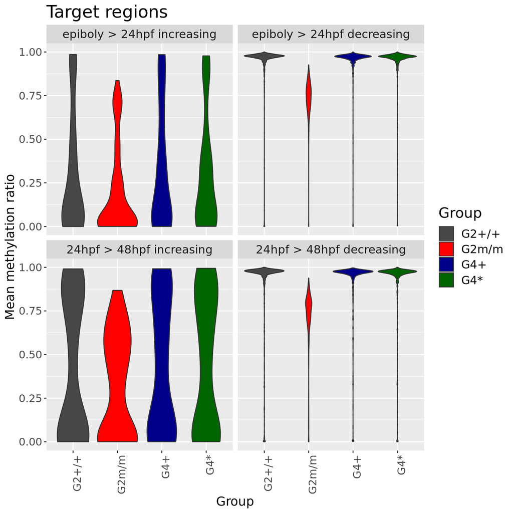

Supplementary Figure 2c: Violin plots of zebrafish early development DMR methylation ratios in normal and affected G2 and G4 zebrafish sperm.

```r
limdat.CC.MeansL <- as.data.frame(limdat.CC.MeansL, stringsAsFactors = FALSE)
limdat.CC.MeansL$Group[limdat.CC.MeansL$Group %in% "G2_WT"] <- "G2+/+"
limdat.CC.MeansL$Group[limdat.CC.MeansL$Group %in% "G2_Mut"] <- "G2m/m"
limdat.CC.MeansL$Group[limdat.CC.MeansL$Group %in% "G4_Pb"] <- "G4*"
limdat.CC.MeansL$Group[limdat.CC.MeansL$Group %in% "G4_Ctrl"] <- "G4+"
limdat.CC.MeansL$Group <- factor(limdat.CC.MeansL$Group, levels = c("G2+/+",
    "G2m/m", "G4+", "G4*"))
limdat.CC.MeansL$Region <- factor(limdat.CC.MeansL$Region, levels = c("epiboly_24hpf_increasing",
    "epiboly_24hpf_decreasing", "24hpf_48hpf_increasing", "24hpf_48hpf_decreasing"))
levels(limdat.CC.MeansL$Region) <- sub("_", " > ", levels(limdat.CC.MeansL$Region))
levels(limdat.CC.MeansL$Region) <- sub("_", " ", levels(limdat.CC.MeansL$Region))


ggplot(data = limdat.CC.MeansL) + geom_violin(aes(x = Group, y = Beta.Mean,
    fill = Group)) + ggtitle("Target regions") + theme(text = element_text(size = 16),
    axis.text = element_text(size = 12), axis.title = element_text(size = 14),
    axis.text.x = element_text(angle = 90, hjust = 1)) + ylab("Mean methylation ratio") +
    scale_fill_manual(values = c("grey28", "red", "darkblue", "darkgreen")) +
    facet_wrap(~Region, nrow = 2)
```

The violin plots show a pronounced hypomethylation of all highly methylated regions in G2m/m fish compared to G2+/+, whereas G4* fish show methylation values undestinguishable from G4+, and G2+/+ fish. On lowly methylated regions (increasing methylation during development), observed impact of Dnmt1 defect in G2m/m fish is lesser.

#### Supplementary Figure 2d: Density plots of zebrafish genomic repeat methylation ratios in normal and affected G2 and G4 zebrafish sperm.

Load zebrafish sperm methylation matrices obtained through averaging of CpG methylation values over target regions :

```r
conL <- c("https://owncloud.gwdg.de/index.php/s/Z1Rab7KdJWdGJEK/download", "https://owncloud.gwdg.de/index.php/s/mYs5jyKUg5b7Kf4/download")
nv <- c("G2", "G4")

limL <- mapply(function(a, b) {
    con <- curl(a, open = "rb")
    load(con)
    close(con)
    limdat.CC <- CGI.limdat.CC[complete.cases(CGI.limdat.CC), ]
    if (b %in% "G4") {
        colnames(limdat.CC)[match(c("5s_A", "6s_A", "10s_A"), colnames(limdat.CC))] <- c("Ctrl1",
            "Ctrl2", "Ctrl3")
        colnames(limdat.CC)[match(c("1s_A", "4s_A", "11s_A"), colnames(limdat.CC))] <- c("Pb1",
            "Pb2", "Pb3")
    } else {
        colnames(limdat.CC)[match(c("Lib_A215_1", "Lib_A215_2", "Lib_A215_3"),
            colnames(limdat.CC))] <- c("Ctrl1", "Ctrl2", "Ctrl3")
        colnames(limdat.CC)[match(c("Lib_A215_4", "Lib_A215_5", "Lib_A215_6"),
            colnames(limdat.CC))] <- c("Pb1", "Pb2", "Pb3")
    }
    limdat.CC$Generation <- b
    rownames(limdat.CC) <- limdat.CC$IntID
    return(limdat.CC)
}, conL, nv, SIMPLIFY = FALSE)

names(limL) <- NULL
limdat <- as.data.frame(do.call(rbind, limL), stringsAsFactors = FALSE)
head(limdat)
```

```
##                    Ctrl1     Ctrl2     Ctrl3       Pb1       Pb2       Pb3
## chr1_1_397     0.7300000 0.8483333 0.8366667 0.5980000 0.7175000 0.7328571
## chr1_4191_4331 1.0000000 0.5933333 0.8200000 0.3100000 0.6700000 0.6866667
## chr1_5118_5691 0.5500000 0.7922222 0.7833333 0.4585714 0.6020000 0.6720000
## chr1_7058_7315 0.9828571 0.9946154 0.9773333 0.8210000 0.8400000 0.9093333
## chr1_7331_7593 0.9235714 0.9150000 0.9214286 0.7850000 0.8557143 0.8877778
## chr1_8034_8228 1.0000000 0.9866667 0.9825000 1.0000000 0.9600000 1.0000000
##                         IntID Generation
## chr1_1_397         chr1_1_397         G2
## chr1_4191_4331 chr1_4191_4331         G2
## chr1_5118_5691 chr1_5118_5691         G2
## chr1_7058_7315 chr1_7058_7315         G2
## chr1_7331_7593 chr1_7331_7593         G2
## chr1_8034_8228 chr1_8034_8228         G2
```

We would like to profile target interval CpG methylation ratio distributions in fish groups. We compute group mean methylation ratios per target region:

```r
limdat.L <- melt(limdat, id.vars = c("IntID", "Generation"), value.name = "Beta",
    variable.name = "Sample")
limdat.L$Sample <- as.character(limdat.L$Sample)
limdat.L$Group <- gsub("[1-3]$", "", limdat.L$Sample)
lg <- group_by(limdat.L, IntID, Generation, Group)
limdat.CC.MeansL <- summarize(lg, Beta.Mean = mean(Beta))

head(limdat.CC.MeansL)
```

```
## # A tibble: 6 x 4
## # Groups:   IntID, Generation [3]
##   IntID                  Generation Group Beta.Mean
##   <chr>                  <chr>      <chr>     <dbl>
## 1 chr1_1_397             G2         Ctrl      0.805
## 2 chr1_1_397             G2         Pb        0.683
## 3 chr1_1_397             G4         Ctrl      0.853
## 4 chr1_1_397             G4         Pb        0.843
## 5 chr1_10000662_10000892 G2         Ctrl      0.83
## 6 chr1_10000662_10000892 G2         Pb        0.242
```

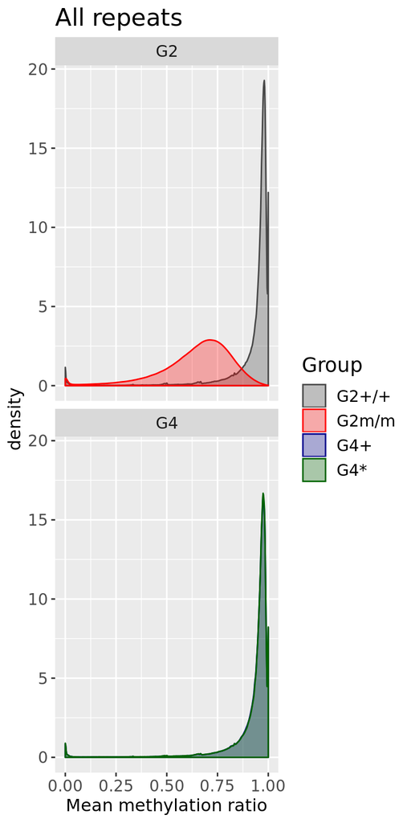

Supplementary Figure 2d: Density plots of zebrafish genomic repeat methylation ratios in normal and affected G2 and G4 zebrafish sperm.

```r
limdat.CC.MeansL <- as.data.frame(limdat.CC.MeansL, stringsAsFactors = FALSE)
limdat.CC.MeansL$Group[limdat.CC.MeansL$Generation %in% "G2" & limdat.CC.MeansL$Group %in%
    "Ctrl"] <- "G2+/+"
limdat.CC.MeansL$Group[limdat.CC.MeansL$Generation %in% "G2" & limdat.CC.MeansL$Group %in%
    "Pb"] <- "G2m/m"
limdat.CC.MeansL$Group[limdat.CC.MeansL$Generation %in% "G4" & limdat.CC.MeansL$Group %in%
    "Pb"] <- "G4*"
limdat.CC.MeansL$Group[limdat.CC.MeansL$Generation %in% "G4" & limdat.CC.MeansL$Group %in%
    "Ctrl"] <- "G4+"
limdat.CC.MeansL$Group <- factor(limdat.CC.MeansL$Group, levels = c("G2+/+",
    "G2m/m", "G4+", "G4*"))
limdat.CC.MeansL$Generation <- factor(limdat.CC.MeansL$Generation, levels = c("G2",
    "G4"))


ggplot(data = limdat.CC.MeansL, aes(x = Beta.Mean)) + geom_density(aes(group = Group,
    colour = Group, fill = Group), alpha = 0.3) + ggtitle("All repeats") + theme(text = element_text(size = 14),
    axis.text = element_text(size = 11), axis.title = element_text(size = 12)) +
    xlab("Mean methylation ratio") + scale_colour_manual(values = c("grey28",
    "red", "darkblue", "darkgreen")) + scale_fill_manual(values = c("grey28",
    "red", "darkblue", "darkgreen")) + facet_wrap(~Generation, nrow = 2)
```

In G2m/m, a wide hypomethylation of repeats highly methylated in G2+/+ can be seen. Both G4+ and G4* show wildtype repeat methylation.

#### Supplementary Figure 5a: Pairwise candidate DMR methylation for G4 zebrafish sperm groups.

Load the G4 zebrafish sperm DMR methylation matrix:

```r
con <- curl("https://owncloud.gwdg.de/index.php/s/m4f74VNi2hhK5LO/download",
    open = "rb")
load(con)
close(con)

head(limdat.LG.CC.Means)
```

```
##          Pb      Ctrl
## 1 0.6554297 0.5593901
## 2 0.8358554 0.6878962
## 3 0.6764878 0.7719325
## 4 0.1637735 0.3702281
## 5 0.8415819 0.6975972
## 6 0.7718099 0.8920011
```

We annotate the data with the filter status on the statistical metric (Pass/Fail) and identify data for rptor and runx3:

```r
con <- curl("https://owncloud.gwdg.de/index.php/s/KxVNGRREIavcA8O/download",
    open = "rb")
load(con)
close(con)

plotdat <- limdat.LG.CC.Means
plotdat$Filter <- "Fail"
plotdat$Filter[rownames(plotdat) %in% rownames(tT.FDR5)] <- "Pass"
plotdat$Diff <- plotdat$Pb - plotdat$Ctrl
auxtab <- plotdat[c("2774", "662"), ]
auxtab$GeneSymbol <- c("-rptor", "-runx3")
auxtab
```

```
##             Pb      Ctrl Filter      Diff GeneSymbol
## 2774 0.9618150 0.5860846   Pass 0.3757304     -rptor
## 662  0.9725951 0.6413146   Pass 0.3312806     -runx3
```

Plot data:

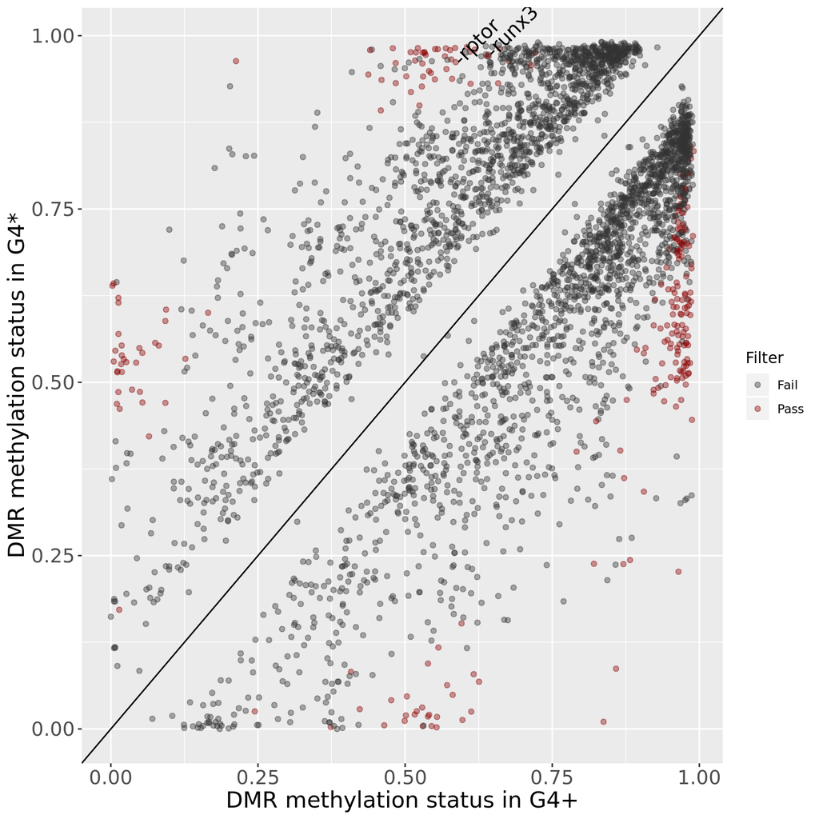

Supplementary Figure 5a: Pairwise candidate DMR methylation for G4 zebrafish sperm groups.

```r
ggplot(data = plotdat) + geom_point(aes(x = Ctrl, y = Pb, colour = Filter),
    alpha = 0.4) + scale_colour_manual(values = c("grey20", "darkred")) + geom_abline(aes(intercept = 0,
    slope = 1)) + geom_text(data = auxtab, aes(x = Ctrl, y = Pb, label = GeneSymbol),
    hjust = 0, nudge_x = 0.001, nudge_y = 0.001, angle = 45, size = 5) + theme(axis.text = element_text(size = 14),
    axis.title = element_text(size = 16), strip.text = element_text(size = 12)) +
    xlab("DMR methylation status in G4+") + ylab("DMR methylation status in G4*")
```

#### Session Info

Time needed to execute the R code in this document:

```r
end_time <- Sys.time()
end_time - start_time
```

```
## Time difference of 18.79704 mins
```